# Random Forest Model

This notebook trains and evaluates a Random Forest classifier for fraud detection using the feature-engineered transaction dataset.

```python
import pandas as pd
import matplotlib.pyplot as plt
import seaborn as sns

from sklearn.model_selection import train_test_split
from sklearn.ensemble import RandomForestClassifier
from sklearn.metrics import classification_report, confusion_matrix, roc_auc_score, ConfusionMatrixDisplay
```

```python
!pip install scikit-learn
```

[output not shown]

```python
df = pd.read_csv(r"C:\Users\USER\Financial-Crime-Analytics-Portfolio\project-1-fraud-detection\data\featured_transactions.csv")
df.head()
```

|  | amount | nameorig | oldbalanceorg | newbalanceorig | namedest | oldbalancedest | newbalancedest | isfraud | isflaggedfraud | origin_balance_diff | dest_balance_diff | origin_amount_error | dest_amount_error | high_risk_type_flag | account_emptied_flag | type_CASH_OUT | type_DEBIT | type_PAYMENT | type_TRANSFER |
| --- | --- | --- | --- | --- | --- | --- | --- | --- | --- | --- | --- | --- | --- | --- | --- | --- | --- | --- | --- |
| 0 | 9839.64 | C1231006815 | 170136.0 | 160296.36 | M1979787155 | 0.0 | 0.0 | 0 | 0 | 9839.64 | 0.0 | -1.455192e-11 | 9839.64 | 0 | 0 | False | False | True | False |
| 1 | 1864.28 | C1666544295 | 21249.0 | 19384.72 | M2044282225 | 0.0 | 0.0 | 0 | 0 | 1864.28 | 0.0 | 1.136868e-12 | 1864.28 | 0 | 0 | False | False | True | False |
| 2 | 181.00 | C1305486145 | 181.0 | 0.00 | C553264065 | 0.0 | 0.0 | 1 | 0 | 181.00 | 0.0 | 0.000000e+00 | 181.00 | 1 | 1 | False | False | False | True |
| 3 | 181.00 | C840083671 | 181.0 | 0.00 | C38997010 | 21182.0 | 0.0 | 1 | 0 | 181.00 | -21182.0 | 0.000000e+00 | 21363.00 | 1 | 1 | True | False | False | False |
| 4 | 11668.14 | C2048537720 | 41554.0 | 29885.86 | M1230701703 | 0.0 | 0.0 | 0 | 0 | 11668.14 | 0.0 | 0.000000e+00 | 11668.14 | 0 | 0 | False | False | True | False |

```python
df = pd.read_csv(r"C:\Users\USER\Financial-Crime-Analytics-Portfolio\project-1-fraud-detection\data\featured_transactions.csv")
df.head()
```

|  | amount | nameorig | oldbalanceorg | newbalanceorig | namedest | oldbalancedest | newbalancedest | isfraud | isflaggedfraud | origin_balance_diff | dest_balance_diff | origin_amount_error | dest_amount_error | high_risk_type_flag | account_emptied_flag | type_CASH_OUT | type_DEBIT | type_PAYMENT | type_TRANSFER |
| --- | --- | --- | --- | --- | --- | --- | --- | --- | --- | --- | --- | --- | --- | --- | --- | --- | --- | --- | --- |
| 0 | 9839.64 | C1231006815 | 170136.0 | 160296.36 | M1979787155 | 0.0 | 0.0 | 0 | 0 | 9839.64 | 0.0 | -1.455192e-11 | 9839.64 | 0 | 0 | False | False | True | False |
| 1 | 1864.28 | C1666544295 | 21249.0 | 19384.72 | M2044282225 | 0.0 | 0.0 | 0 | 0 | 1864.28 | 0.0 | 1.136868e-12 | 1864.28 | 0 | 0 | False | False | True | False |
| 2 | 181.00 | C1305486145 | 181.0 | 0.00 | C553264065 | 0.0 | 0.0 | 1 | 0 | 181.00 | 0.0 | 0.000000e+00 | 181.00 | 1 | 1 | False | False | False | True |
| 3 | 181.00 | C840083671 | 181.0 | 0.00 | C38997010 | 21182.0 | 0.0 | 1 | 0 | 181.00 | -21182.0 | 0.000000e+00 | 21363.00 | 1 | 1 | True | False | False | False |
| 4 | 11668.14 | C2048537720 | 41554.0 | 29885.86 | M1230701703 | 0.0 | 0.0 | 0 | 0 | 11668.14 | 0.0 | 0.000000e+00 | 11668.14 | 0 | 0 | False | False | True | False |

```python
X = df.drop(columns=["isfraud", "nameorig", "namedest"], errors="ignore")
y = df["isfraud"]
```

```python
print("X shape:", X.shape)
print("y shape:", y.shape)
```

```
X shape: (1048575, 16)
y shape: (1048575,)
```

```python
y.value_counts(normalize=True)
```

```
isfraud
0    0.998911
1    0.001089
Name: proportion, dtype: float64
```

```python
y.value_counts(normalize=True)
```

```
isfraud
0    0.998911
1    0.001089
Name: proportion, dtype: float64
```

## Train-Test Split

The dataset is divided into training and testing subsets. Stratified sampling is used to preserve the fraud class distribution in both sets.

```python
X_train, X_test, y_train, y_test = train_test_split(
    X, y, test_size=0.2, random_state=42, stratify=y
)
```

```python
print("X_train:", X_train.shape)
print("X_test:", X_test.shape)
print("y_train:", y_train.shape)
print("y_test:", y_test.shape)
```

```
X_train: (838860, 16)
X_test: (209715, 16)
y_train: (838860,)
y_test: (209715,)
```

## Model Training

A Random Forest classifier is trained using balanced class weights to account for class imbalance in the fraud target.

```python
rf = RandomForestClassifier(
    n_estimators=100,
    random_state=42,
    class_weight="balanced"
)
rf.fit(X_train, y_train)
```

```
RandomForestClassifier(class_weight='balanced', random_state=42)
```

```python
y_pred = rf.predict(X_test)
y_prob = rf.predict_proba(X_test)[:, 1]
```

```python
import os

os.makedirs("../outputs", exist_ok=True)
```

## Model Evaluation

The model is evaluated using classification metrics and ROC-AUC. Special attention is given to fraud-class precision, recall, and F1-score.

```python
y_pred = rf.predict(X_test)
y_prob = rf.predict_proba(X_test)[:, 1]
```

```python
print(classification_report(y_test, y_pred))
print("ROC-AUC:", roc_auc_score(y_test, y_prob))
```

```
              precision    recall  f1-score   support

           0       1.00      1.00      1.00    209487
           1       1.00      0.98      0.99       228

    accuracy                           1.00    209715
   macro avg       1.00      0.99      0.99    209715
weighted avg       1.00      1.00      1.00    209715

ROC-AUC: 0.9890191758329601
```

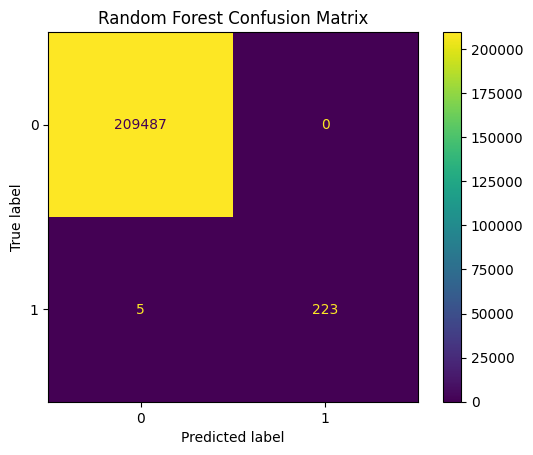

```python
cm = confusion_matrix(y_test, y_pred)
disp = ConfusionMatrixDisplay(confusion_matrix=cm)
disp.plot()
plt.title("Random Forest Confusion Matrix")
plt.savefig(r"C:\Users\USER\Financial-Crime-Analytics-Portfolio\project-1-fraud-detection\outputs\random_forest_confusion_matrix.png", bbox_inches="tight")
plt.show()
```

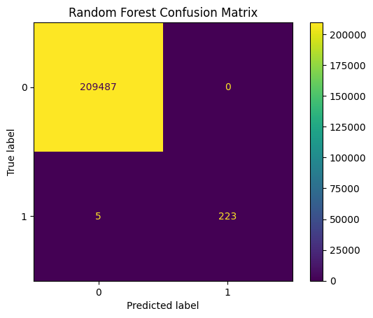

```python
from sklearn.metrics import confusion_matrix, ConfusionMatrixDisplay
import matplotlib.pyplot as plt

cm = confusion_matrix(y_test, y_pred)

disp = ConfusionMatrixDisplay(confusion_matrix=cm)
disp.plot()

plt.title("Random Forest Confusion Matrix")

plt.savefig(
    r"C:\Users\USER\Financial-Crime-Analytics-Portfolio\project-1-fraud-detection\outputs\random_forest_confusion_matrix.png",
    bbox_inches="tight"
)

plt.show()
```

## Feature Importance

Feature importance scores are used to identify the variables that contribute most to fraud prediction.

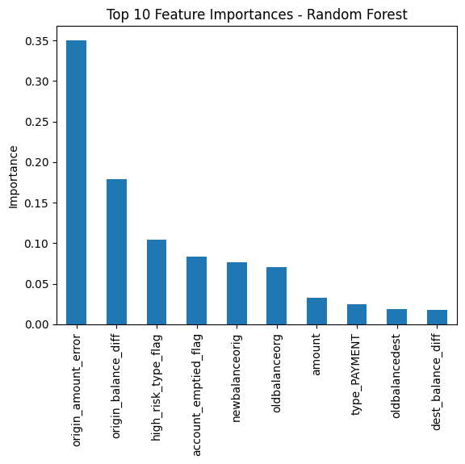

```python
importances = pd.Series(rf.feature_importances_, index=X.columns).sort_values(ascending=False).head(10)
importances.plot(kind="bar")
plt.title("Top 10 Feature Importances - Random Forest")
plt.ylabel("Importance")
plt.savefig("../outputs/random_forest_feature_importance.png", bbox_inches="tight")
plt.show()
```

## Feature Importance

Feature importance scores are used to identify the variables that contribute most to fraud prediction.

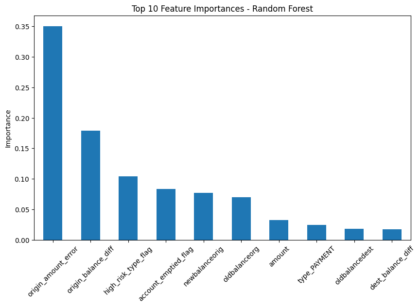

```python
importances = pd.Series(rf.feature_importances_, index=X.columns).sort_values(ascending=False).head(10)

plt.figure(figsize=(10, 6))
importances.plot(kind="bar")
plt.title("Top 10 Feature Importances - Random Forest")
plt.ylabel("Importance")
plt.xticks(rotation=45)
plt.savefig("../outputs/random_forest_feature_importance.png", bbox_inches="tight")
plt.show()
```

## Random Forest Summary

The Random Forest model was trained on the feature-engineered transaction dataset and evaluated on a stratified test set. The model achieved strong discrimination performance based on ROC-AUC and showed the ability to identify fraudulent transactions. Feature importance results indicate that balance-related error features and high-risk transaction indicators are among the strongest predictors of fraud.